# 1-5. DecisionTree segmentation

```python
import pandas as pd
import numpy as np
import matplotlib.pyplot as plt
import matplotlib
import seaborn as sns
from sklearn.preprocessing import StandardScaler
from sklearn.model_selection import train_test_split
from statsmodels.api import Logit
from sklearn.metrics import accuracy_score,f1_score
from sklearn.metrics import confusion_matrix, classification_report
from sklearn.tree import DecisionTreeRegressor
from sklearn.ensemble import RandomForestRegressor
from sklearn.metrics import mean_squared_error
from sklearn.metrics import mean_absolute_error
from sklearn.ensemble import GradientBoostingRegressor
from sklearn.linear_model import LinearRegression
from sklearn.feature_selection import RFE
import pandas as pd
import statsmodels.formula.api as smf
from statsmodels.stats.outliers_influence import variance_inflation_factor
import matplotlib.pyplot as plt
import matplotlib
from sklearn.tree import export_graphviz
import graphviz
from sklearn.model_selection import train_test_split
from sklearn.tree import DecisionTreeClassifier
from sklearn.svm import SVC
from sklearn.model_selection import GridSearchCV
from sklearn.metrics import accuracy_score,f1_score
from sklearn.metrics import confusion_matrix, classification_report
from sklearn.neural_network import MLPClassifier
from sklearn.ensemble import RandomForestClassifier
from sklearn.ensemble import RandomForestRegressor
from sklearn.ensemble import GradientBoostingRegressor
from sklearn.ensemble import GradientBoostingClassifier
from sklearn.neural_network import MLPClassifier
from sklearn.metrics import precision_score, recall_score, f1_score,roc_curve, auc
from statsmodels.api import qqplot, add_constant
from sklearn.decomposition import PCA
import statsmodels.api as sm
```

```python
# 리눅스 폰트 적용
%matplotlib inline

import platform
platform.platform()

import sys
sys.version_info

!apt-get install -y fonts-nanum
!ls -l /usr/share/fonts/truetype/
!rm -rf ~/.cache/matplotlib/*
!fc-cache -fv

import matplotlib
import matplotlib.font_manager
[f.name for f in matplotlib.font_manager.fontManager.ttflist if 'Nanum' in f.name]

import matplotlib as mpl
mpl.rcParams['axes.unicode_minus'] = False
plt.rcParams["font.family"] = 'NanumGothic'
```

[output not shown]

[output cut: 132 more lines]

[output not shown]

## 전체

```python
df = pd.read_csv("new_telco_customer.csv")
```

```python
df
```

|  | Unnamed: 0 | CustomerId | Gender | Age | AgeGroup | Married | Dependents | noDependents | Referrals | noReferrals | ... | CustomerLTV | SatisScore | TotalExtraDataCharge | AvgRoamCharge | TotalRoamCharge | TotalCharge | AvgCharge | TotalRevenue | TenureMonths | noService |
| --- | --- | --- | --- | --- | --- | --- | --- | --- | --- | --- | --- | --- | --- | --- | --- | --- | --- | --- | --- | --- | --- |
| 0 | 0 | C-10001 | 여성 | 37 | 30대 | Yes | No | 0 | Yes | 2 | ... | 2205 | 3 | 0 | 47910 | 431100 | 1755400 | 83590 | 2186500 | 21 | 2 |
| 1 | 1 | C-10002 | 남성 | 46 | 40대 | No | No | 0 | No | 0 | ... | 5414 | 5 | 11300 | 12090 | 108710 | 1447500 | 68928 | 1567510 | 21 | 0 |
| 2 | 2 | C-10003 | 남성 | 50 | 50대 | No | No | 0 | No | 0 | ... | 4479 | 1 | 0 | 38080 | 152100 | 490900 | 98180 | 643000 | 4 | 0 |
| 3 | 3 | C-10004 | 남성 | 78 | 70대 | Yes | No | 0 | Yes | 1 | ... | 3714 | 1 | 0 | 31410 | 408720 | 1578400 | 112742 | 1987120 | 13 | 1 |
| 4 | 4 | C-10005 | 여성 | 75 | 70대 | Yes | No | 0 | Yes | 3 | ... | 3464 | 1 | 0 | 8360 | 24970 | 378000 | 94500 | 402970 | 3 | 1 |
| ... | ... | ... | ... | ... | ... | ... | ... | ... | ... | ... | ... | ... | ... | ... | ... | ... | ... | ... | ... | ... | ... |
| 6858 | 6858 | C-17039 | 여성 | 20 | 20대 | No | No | 0 | No | 0 | ... | 3161 | 4 | 0 | 52770 | 685680 | 1610700 | 64428 | 2296380 | 25 | 2 |
| 6859 | 6859 | C-17040 | 남성 | 40 | 40대 | Yes | No | 0 | Yes | 1 | ... | 5248 | 1 | 0 | 18310 | 402730 | 2343500 | 101891 | 2746230 | 22 | 0 |
| 6860 | 6860 | C-17041 | 남성 | 22 | 20대 | No | No | 0 | No | 0 | ... | 5870 | 5 | 0 | 21020 | 42040 | 792400 | 56600 | 834440 | 14 | 1 |
| 6861 | 6861 | C-17042 | 남성 | 21 | 20대 | No | No | 0 | Yes | 5 | ... | 4792 | 3 | 0 | 2370 | 160460 | 6328500 | 80107 | 6488960 | 79 | 2 |
| 6862 | 6862 | C-17043 | 남성 | 36 | 30대 | Yes | No | 0 | Yes | 1 | ... | 5639 | 3 | 0 | 0 | 0 | 5196100 | 69281 | 5196100 | 75 | 2 |

6863 rows × 34 columns

```python
df.drop(['Unnamed: 0'],axis=1 , inplace = True)
df.describe()
```

|  | Age | noDependents | noReferrals | AvgDownloadGB | ChurnScore | CustomerLTV | SatisScore | TotalExtraDataCharge | AvgRoamCharge | TotalRoamCharge | TotalCharge | AvgCharge | TotalRevenue | TenureMonths | noService |
| --- | --- | --- | --- | --- | --- | --- | --- | --- | --- | --- | --- | --- | --- | --- | --- |
| count | 6863.000000 | 6863.000000 | 6863.000000 | 6863.000000 | 6863.000000 | 6863.000000 | 6863.000000 | 6863.000000 | 6863.000000 | 6.863000e+03 | 6.863000e+03 | 6863.000000 | 6.863000e+03 | 6863.000000 | 6863.000000 |
| mean | 46.606877 | 0.411482 | 1.990675 | 20.507358 | 58.133324 | 4412.442372 | 3.278304 | 7916.421390 | 25966.319394 | 8.674697e+05 | 3.423892e+06 | 76482.821361 | 4.299278e+06 | 42.201952 | 0.939677 |
| std | 16.581750 | 0.879672 | 3.024032 | 20.424957 | 21.408509 | 1180.383953 | 1.188723 | 28684.745619 | 17477.405921 | 9.601166e+05 | 3.008542e+06 | 35527.411892 | 3.659638e+06 | 26.455574 | 1.018413 |
| min | 20.000000 | 0.000000 | 0.000000 | 0.000000 | 5.000000 | 2003.000000 | 1.000000 | 0.000000 | 0.000000 | 0.000000e+00 | 4.240000e+04 | 20807.000000 | 4.590000e+04 | 1.000000 | 0.000000 |
| 25% | 32.000000 | 0.000000 | 0.000000 | 3.000000 | 40.000000 | 3487.000000 | 3.000000 | 0.000000 | 10400.000000 | 9.441500e+04 | 9.770000e+05 | 42284.500000 | 1.272825e+06 | 18.000000 | 0.000000 |
| 50% | 46.000000 | 0.000000 | 0.000000 | 17.000000 | 60.000000 | 4538.000000 | 3.000000 | 0.000000 | 25990.000000 | 4.860100e+05 | 2.310800e+06 | 83194.000000 | 3.156600e+06 | 39.000000 | 1.000000 |
| 75% | 60.000000 | 0.000000 | 3.000000 | 27.000000 | 75.000000 | 5388.000000 | 4.000000 | 0.000000 | 41250.000000 | 1.379790e+06 | 5.482450e+06 | 106070.000000 | 6.683200e+06 | 67.000000 | 2.000000 |
| max | 80.000000 | 4.000000 | 11.000000 | 85.000000 | 100.000000 | 6500.000000 | 5.000000 | 169500.000000 | 56500.000000 | 4.028110e+06 | 1.167510e+07 | 140905.000000 | 1.553714e+07 | 84.000000 | 3.000000 |

- 전체집단
  - ltv의 평균: 4412.44
  - Avgcharge의 평균: 76,482.82원
  - noService: 0.939
  - AvgDownloadGB: 20.51

## 이탈률 = 54.471%인 모델(Churn)

```python
df = pd.read_csv("new_telco_customer.csv")
df['Dependents']=df['Dependents'].map({'No':0,'Yes':1})
df['Referrals']=df['Referrals'].map({'No':0,'Yes':1})
df['PaperlessBilling']=df['PaperlessBilling'].map({'No':0,'Yes':1})
```

```python
for i in range(len(df)):
    if (df['noReferrals'][i] <=1.5) & (df['AvgDownloadGB'][i] >1):
        if (df['noService'][i] <=0.5) & (df['AvgCharge'][i]>82875) :
            if df['PaperlessBilling'][i]<=0.5:
                continue
            else :
                df=df.drop([i],axis=0)
        else :
            df=df.drop([i],axis=0)
    else:
        df=df.drop([i],axis=0)
```

```python
df = pd.read_csv("new_telco_customer.csv")
```

```python
df.describe()
```

|  | Unnamed: 0 | Age | noDependents | noReferrals | AvgDownloadGB | ChurnScore | CustomerLTV | SatisScore | TotalExtraDataCharge | AvgRoamCharge | TotalRoamCharge | TotalCharge | AvgCharge | TotalRevenue | TenureMonths | noService |
| --- | --- | --- | --- | --- | --- | --- | --- | --- | --- | --- | --- | --- | --- | --- | --- | --- |
| count | 6863.000000 | 6863.000000 | 6863.000000 | 6863.000000 | 6863.000000 | 6863.000000 | 6863.000000 | 6863.000000 | 6863.000000 | 6863.000000 | 6.863000e+03 | 6.863000e+03 | 6863.000000 | 6.863000e+03 | 6863.000000 | 6863.000000 |
| mean | 3431.000000 | 46.606877 | 0.411482 | 1.990675 | 20.507358 | 58.133324 | 4412.442372 | 3.278304 | 7916.421390 | 25966.319394 | 8.674697e+05 | 3.423892e+06 | 76482.821361 | 4.299278e+06 | 42.201952 | 0.939677 |
| std | 1981.321781 | 16.581750 | 0.879672 | 3.024032 | 20.424957 | 21.408509 | 1180.383953 | 1.188723 | 28684.745619 | 17477.405921 | 9.601166e+05 | 3.008542e+06 | 35527.411892 | 3.659638e+06 | 26.455574 | 1.018413 |
| min | 0.000000 | 20.000000 | 0.000000 | 0.000000 | 0.000000 | 5.000000 | 2003.000000 | 1.000000 | 0.000000 | 0.000000 | 0.000000e+00 | 4.240000e+04 | 20807.000000 | 4.590000e+04 | 1.000000 | 0.000000 |
| 25% | 1715.500000 | 32.000000 | 0.000000 | 0.000000 | 3.000000 | 40.000000 | 3487.000000 | 3.000000 | 0.000000 | 10400.000000 | 9.441500e+04 | 9.770000e+05 | 42284.500000 | 1.272825e+06 | 18.000000 | 0.000000 |
| 50% | 3431.000000 | 46.000000 | 0.000000 | 0.000000 | 17.000000 | 60.000000 | 4538.000000 | 3.000000 | 0.000000 | 25990.000000 | 4.860100e+05 | 2.310800e+06 | 83194.000000 | 3.156600e+06 | 39.000000 | 1.000000 |
| 75% | 5146.500000 | 60.000000 | 0.000000 | 3.000000 | 27.000000 | 75.000000 | 5388.000000 | 4.000000 | 0.000000 | 41250.000000 | 1.379790e+06 | 5.482450e+06 | 106070.000000 | 6.683200e+06 | 67.000000 | 2.000000 |
| max | 6862.000000 | 80.000000 | 4.000000 | 11.000000 | 85.000000 | 100.000000 | 6500.000000 | 5.000000 | 169500.000000 | 56500.000000 | 4.028110e+06 | 1.167510e+07 | 140905.000000 | 1.553714e+07 | 84.000000 | 3.000000 |

```python
df.drop(['Unnamed: 0'],axis=1 , inplace = True)
df.describe()
```

[output not shown]

- 전체집단
  - ltv의 평균: 4412.44
  - Avgcharge의 평균: 76,482.82원
  - noService: 0.939
  - AvgDownloadGB: 20.51

#### 1. 모델2(Churn)의 LTV 평균은 "4002.51"으로 전체집단의 평균보다 낮다.

#### 2. 모델2(Churn)의 AvgCharge 평균은 "97,951.89" 으로 전체집단의 평균보다 높다.

#### 3. 모델2(Churn)의 AvgDownloadGB 평균은 "24.92" 으로 전체집단의 평균보다 높다.

#### 4. 모델2(Churn)의 noService 평균은 "0"으로 서비스를 이용하는 고객은 없다.

#### 5. 모델2(Churn)의 value = [56,67] / 이탈률 = 54.471%

## => AvgCharge,AvgDownloadGB 높음 / LTV 평균,noService 낮음

## => AvgRoamCharge 높음 / noDependents,Referrals, TotalExtraDataCharge, TenureMonths 낮음

## 이탈률 = 68.468%인 모델(Churn)

```python
df = pd.read_csv("new_telco_customer.csv")
df['Dependents']=df['Dependents'].map({'No':0,'Yes':1})
df['Referrals']=df['Referrals'].map({'No':0,'Yes':1})
df['PaperlessBilling']=df['PaperlessBilling'].map({'No':0,'Yes':1})
```

```python
for i in range(len(df)):
    if (df['noReferrals'][i] <=1.5) & (df['AvgDownloadGB'][i] >1):
        if (df['noService'][i] <=0.5) & (df['AvgCharge'][i]>82875) :
            if df['PaperlessBilling'][i]>0.5:
                continue
            else :
                df=df.drop([i],axis=0)
        else :
            df=df.drop([i],axis=0)
    else:
        df=df.drop([i],axis=0)
```

```python
df.drop(['Unnamed: 0'],axis=1 , inplace = True)
df.describe()
```

|  | Age | Dependents | noDependents | Referrals | noReferrals | PaperlessBilling | AvgDownloadGB | ChurnScore | CustomerLTV | SatisScore | TotalExtraDataCharge | AvgRoamCharge | TotalRoamCharge | TotalCharge | AvgCharge | TotalRevenue | TenureMonths | noService |
| --- | --- | --- | --- | --- | --- | --- | --- | --- | --- | --- | --- | --- | --- | --- | --- | --- | --- | --- |
| count | 633.000000 | 633.000000 | 633.000000 | 633.000000 | 633.000000 | 633.0 | 633.000000 | 633.000000 | 633.000000 | 633.000000 | 633.000000 | 633.000000 | 6.330000e+02 | 6.330000e+02 | 633.000000 | 6.330000e+02 | 633.000000 | 633.0 |
| mean | 52.581359 | 0.044234 | 0.080569 | 0.241706 | 0.241706 | 1.0 | 22.491311 | 72.494471 | 4089.530806 | 2.472354 | 9068.562401 | 28567.172196 | 5.050367e+05 | 2.209536e+06 | 100053.802528 | 2.723641e+06 | 20.838863 | 0.0 |
| std | 17.733437 | 0.205777 | 0.403488 | 0.428456 | 0.428456 | 0.0 | 16.635814 | 20.047421 | 1201.713388 | 1.285118 | 29925.075859 | 15904.491536 | 6.275015e+05 | 2.007180e+06 | 10683.448703 | 2.535494e+06 | 18.783559 | 0.0 |
| min | 20.000000 | 0.000000 | 0.000000 | 0.000000 | 0.000000 | 1.0 | 2.000000 | 20.000000 | 2003.000000 | 1.000000 | 0.000000 | 1240.000000 | 1.240000e+03 | 1.662000e+05 | 82912.000000 | 1.825100e+05 | 1.000000 | 0.0 |
| 25% | 37.000000 | 0.000000 | 0.000000 | 0.000000 | 0.000000 | 1.0 | 11.000000 | 66.000000 | 3056.000000 | 1.000000 | 0.000000 | 14580.000000 | 7.978000e+04 | 6.495000e+05 | 91028.000000 | 7.974700e+05 | 5.000000 | 0.0 |
| 50% | 54.000000 | 0.000000 | 0.000000 | 0.000000 | 0.000000 | 1.0 | 19.000000 | 76.000000 | 4164.000000 | 2.000000 | 0.000000 | 28820.000000 | 2.625000e+05 | 1.536400e+06 | 99064.000000 | 1.833250e+06 | 15.000000 | 0.0 |
| 75% | 68.000000 | 0.000000 | 0.000000 | 0.000000 | 0.000000 | 1.0 | 27.000000 | 87.000000 | 5158.000000 | 3.000000 | 0.000000 | 42600.000000 | 6.619500e+05 | 3.246400e+06 | 108600.000000 | 3.950530e+06 | 31.000000 | 0.0 |
| max | 80.000000 | 1.000000 | 3.000000 | 1.000000 | 1.000000 | 1.0 | 85.000000 | 100.000000 | 6483.000000 | 5.000000 | 169500.000000 | 56270.000000 | 3.399380e+06 | 9.795400e+06 | 140700.000000 | 1.247499e+07 | 84.000000 | 0.0 |

```python
df = pd.read_csv("new_telco_customer.csv")
df.describe()
```

|  | Unnamed: 0 | Age | noDependents | noReferrals | AvgDownloadGB | ChurnScore | CustomerLTV | SatisScore | TotalExtraDataCharge | AvgRoamCharge | TotalRoamCharge | TotalCharge | AvgCharge | TotalRevenue | TenureMonths | noService |
| --- | --- | --- | --- | --- | --- | --- | --- | --- | --- | --- | --- | --- | --- | --- | --- | --- |
| count | 6863.000000 | 6863.000000 | 6863.000000 | 6863.000000 | 6863.000000 | 6863.000000 | 6863.000000 | 6863.000000 | 6863.000000 | 6863.000000 | 6.863000e+03 | 6.863000e+03 | 6863.000000 | 6.863000e+03 | 6863.000000 | 6863.000000 |
| mean | 3431.000000 | 46.606877 | 0.411482 | 1.990675 | 20.507358 | 58.133324 | 4412.442372 | 3.278304 | 7916.421390 | 25966.319394 | 8.674697e+05 | 3.423892e+06 | 76482.821361 | 4.299278e+06 | 42.201952 | 0.939677 |
| std | 1981.321781 | 16.581750 | 0.879672 | 3.024032 | 20.424957 | 21.408509 | 1180.383953 | 1.188723 | 28684.745619 | 17477.405921 | 9.601166e+05 | 3.008542e+06 | 35527.411892 | 3.659638e+06 | 26.455574 | 1.018413 |
| min | 0.000000 | 20.000000 | 0.000000 | 0.000000 | 0.000000 | 5.000000 | 2003.000000 | 1.000000 | 0.000000 | 0.000000 | 0.000000e+00 | 4.240000e+04 | 20807.000000 | 4.590000e+04 | 1.000000 | 0.000000 |
| 25% | 1715.500000 | 32.000000 | 0.000000 | 0.000000 | 3.000000 | 40.000000 | 3487.000000 | 3.000000 | 0.000000 | 10400.000000 | 9.441500e+04 | 9.770000e+05 | 42284.500000 | 1.272825e+06 | 18.000000 | 0.000000 |
| 50% | 3431.000000 | 46.000000 | 0.000000 | 0.000000 | 17.000000 | 60.000000 | 4538.000000 | 3.000000 | 0.000000 | 25990.000000 | 4.860100e+05 | 2.310800e+06 | 83194.000000 | 3.156600e+06 | 39.000000 | 1.000000 |
| 75% | 5146.500000 | 60.000000 | 0.000000 | 3.000000 | 27.000000 | 75.000000 | 5388.000000 | 4.000000 | 0.000000 | 41250.000000 | 1.379790e+06 | 5.482450e+06 | 106070.000000 | 6.683200e+06 | 67.000000 | 2.000000 |
| max | 6862.000000 | 80.000000 | 4.000000 | 11.000000 | 85.000000 | 100.000000 | 6500.000000 | 5.000000 | 169500.000000 | 56500.000000 | 4.028110e+06 | 1.167510e+07 | 140905.000000 | 1.553714e+07 | 84.000000 | 3.000000 |

```python
df.drop(['Unnamed: 0'],axis=1 , inplace = True)
df.describe()
```

- 전체집단
  - ltv의 평균: 4412.44
  - Avgcharge의 평균: 76,482.82원
  - noService: 0.939
  - AvgDownloadGB: 20.51

#### 1. 모델3(Churn)의 LTV 평균은 "4089.53"으로 전체집단의 평균보다 낮다.

#### 2. 모델3(Churn)의 AvgCharge 평균은 "100,053.80"으로 전체집단 평균보다 높다.

#### 3. 모델3(Churn)의 AvgDownloadGB 평균은 "22.49"으로 전체집단 평균보다 높다.

## 이탈률 = 5.993%인 모델(NoChurn)

```python
df = pd.read_csv("new_telco_customer.csv")
df['Dependents']=df['Dependents'].map({'No':0,'Yes':1})
df['Referrals']=df['Referrals'].map({'No':0,'Yes':1})
df['PaperlessBilling']=df['PaperlessBilling'].map({'No':0,'Yes':1})
```

```python
for i in range(len(df)):
    if (df['noReferrals'][i] <=1.5) & (df['AvgDownloadGB'][i] <=1):
        if (df['AvgCharge'][i] >22743.5) & (df['AvgCharge'][i]>23348) :
            if (df['AvgCharge'][i]>23812):
                continue
            else:
                df=df.drop([i],axis=0)
        else:
            df=df.drop([i],axis=0)
    else:
        df=df.drop([i],axis=0)
```

```python
df.drop(['Unnamed: 0'],axis=1 , inplace = True)
df.describe()
```

|  | Age | Dependents | noDependents | Referrals | noReferrals | PaperlessBilling | AvgDownloadGB | ChurnScore | CustomerLTV | SatisScore | TotalExtraDataCharge | AvgRoamCharge | TotalRoamCharge | TotalCharge | AvgCharge | TotalRevenue | TenureMonths | noService |
| --- | --- | --- | --- | --- | --- | --- | --- | --- | --- | --- | --- | --- | --- | --- | --- | --- | --- | --- |
| count | 443.000000 | 443.000000 | 443.000000 | 443.000000 | 443.000000 | 443.000000 | 443.0 | 443.000000 | 443.000000 | 443.000000 | 443.0 | 443.000000 | 4.430000e+02 | 4.430000e+02 | 443.000000 | 4.430000e+02 | 443.000000 | 443.0 |
| mean | 42.785553 | 0.225734 | 0.451467 | 0.209932 | 0.209932 | 0.300226 | 0.0 | 53.968397 | 4335.185102 | 3.871332 | 0.0 | 28492.618510 | 8.784244e+05 | 1.138340e+06 | 26688.467269 | 2.016765e+06 | 41.803612 | 0.0 |
| std | 14.392889 | 0.418537 | 0.924413 | 0.407720 | 0.407720 | 0.458874 | 0.0 | 19.192615 | 1221.506316 | 0.943741 | 0.0 | 15788.131243 | 9.355453e+05 | 7.272964e+05 | 2503.049299 | 1.544900e+06 | 25.073192 | 0.0 |
| min | 20.000000 | 0.000000 | 0.000000 | 0.000000 | 0.000000 | 0.000000 | 0.0 | 8.000000 | 2010.000000 | 1.000000 | 0.0 | 1240.000000 | 1.810000e+03 | 4.830000e+04 | 23818.000000 | 6.604000e+04 | 1.000000 | 0.0 |
| 25% | 30.000000 | 0.000000 | 0.000000 | 0.000000 | 0.000000 | 0.000000 | 0.0 | 38.500000 | 3372.000000 | 3.000000 | 0.0 | 15480.000000 | 1.292750e+05 | 4.600000e+05 | 24250.500000 | 6.433300e+05 | 18.000000 | 0.0 |
| 50% | 42.000000 | 0.000000 | 0.000000 | 0.000000 | 0.000000 | 0.000000 | 0.0 | 55.000000 | 4416.000000 | 4.000000 | 0.0 | 28930.000000 | 5.289500e+05 | 9.307000e+05 | 25756.000000 | 1.560590e+06 | 36.000000 | 0.0 |
| 75% | 54.500000 | 0.000000 | 0.000000 | 0.000000 | 0.000000 | 1.000000 | 0.0 | 70.000000 | 5388.000000 | 5.000000 | 0.0 | 40910.000000 | 1.359790e+06 | 1.758700e+06 | 29105.500000 | 3.095025e+06 | 65.000000 | 0.0 |
| max | 80.000000 | 1.000000 | 4.000000 | 1.000000 | 1.000000 | 1.000000 | 0.0 | 99.000000 | 6499.000000 | 5.000000 | 0.0 | 56500.000000 | 3.851830e+06 | 2.645000e+06 | 32700.000000 | 6.274730e+06 | 84.000000 | 0.0 |

```python
df = pd.read_csv("new_telco_customer.csv")
df.describe()
```

|  | Unnamed: 0 | Age | noDependents | noReferrals | AvgDownloadGB | ChurnScore | CustomerLTV | SatisScore | TotalExtraDataCharge | AvgRoamCharge | TotalRoamCharge | TotalCharge | AvgCharge | TotalRevenue | TenureMonths | noService |
| --- | --- | --- | --- | --- | --- | --- | --- | --- | --- | --- | --- | --- | --- | --- | --- | --- |
| count | 6863.000000 | 6863.000000 | 6863.000000 | 6863.000000 | 6863.000000 | 6863.000000 | 6863.000000 | 6863.000000 | 6863.000000 | 6863.000000 | 6.863000e+03 | 6.863000e+03 | 6863.000000 | 6.863000e+03 | 6863.000000 | 6863.000000 |
| mean | 3431.000000 | 46.606877 | 0.411482 | 1.990675 | 20.507358 | 58.133324 | 4412.442372 | 3.278304 | 7916.421390 | 25966.319394 | 8.674697e+05 | 3.423892e+06 | 76482.821361 | 4.299278e+06 | 42.201952 | 0.939677 |
| std | 1981.321781 | 16.581750 | 0.879672 | 3.024032 | 20.424957 | 21.408509 | 1180.383953 | 1.188723 | 28684.745619 | 17477.405921 | 9.601166e+05 | 3.008542e+06 | 35527.411892 | 3.659638e+06 | 26.455574 | 1.018413 |
| min | 0.000000 | 20.000000 | 0.000000 | 0.000000 | 0.000000 | 5.000000 | 2003.000000 | 1.000000 | 0.000000 | 0.000000 | 0.000000e+00 | 4.240000e+04 | 20807.000000 | 4.590000e+04 | 1.000000 | 0.000000 |
| 25% | 1715.500000 | 32.000000 | 0.000000 | 0.000000 | 3.000000 | 40.000000 | 3487.000000 | 3.000000 | 0.000000 | 10400.000000 | 9.441500e+04 | 9.770000e+05 | 42284.500000 | 1.272825e+06 | 18.000000 | 0.000000 |
| 50% | 3431.000000 | 46.000000 | 0.000000 | 0.000000 | 17.000000 | 60.000000 | 4538.000000 | 3.000000 | 0.000000 | 25990.000000 | 4.860100e+05 | 2.310800e+06 | 83194.000000 | 3.156600e+06 | 39.000000 | 1.000000 |
| 75% | 5146.500000 | 60.000000 | 0.000000 | 3.000000 | 27.000000 | 75.000000 | 5388.000000 | 4.000000 | 0.000000 | 41250.000000 | 1.379790e+06 | 5.482450e+06 | 106070.000000 | 6.683200e+06 | 67.000000 | 2.000000 |
| max | 6862.000000 | 80.000000 | 4.000000 | 11.000000 | 85.000000 | 100.000000 | 6500.000000 | 5.000000 | 169500.000000 | 56500.000000 | 4.028110e+06 | 1.167510e+07 | 140905.000000 | 1.553714e+07 | 84.000000 | 3.000000 |

- 전체집단
  - ltv의 평균: 4412.44
  - Avgcharge의 평균: 76,482.82원
  - noService: 0.939
  - AvgDownloadGB: 20.51

#### 1. 모델4(NoChurn)의 LTV 평균은 "4335.19"으로 전체평균보다 낮다.

#### 2. 모델4(NoChurn)의 AvgCharge 평균은 "26,688.47"으로 전체 평균보다 낮다.

#### 3. 모델4(NoChurn)의 AvgDownloadGB 평균은 "0"으로 AvgDownloadGB를 이용하는 고객은 없다.

#### 4. 모델4(NoChurn)의 noService 평균은 "0"으로 서비스를 이용하는 고객은 없다.

#### 5. 모델4(NoChurn)의 value = [298,19] / 이탈률 = 5.993%

## => LTV,AvgCharge,AvgDownloadGB,noService 낮음

## => noDependents,AvgRoamCharge 높음 / TotalExtraDataCharge,TenureMonths낮음

## 이탈률 = 0%인 모델(NoChurn)

```python
df = pd.read_csv("new_telco_customer.csv")
df['Dependents']=df['Dependents'].map({'No':0,'Yes':1})
df['Referrals']=df['Referrals'].map({'No':0,'Yes':1})
df['PaperlessBilling']=df['PaperlessBilling'].map({'No':0,'Yes':1})
```

```python
for i in range(len(df)):
    if (df['noReferrals'][i] >1.5) & (df['noReferrals'][i] >5.5):
        if (df['AvgCharge'][i] <=110472) & (df['Age'][i]>31.5) :
            if (df['AvgRoamCharge'][i]>7405):
                continue
            else:
                df=df.drop([i],axis=0)
        else:
            df=df.drop([i],axis=0)
    else:
        df=df.drop([i],axis=0)
```

```python
df.drop(['Unnamed: 0'],axis=1 , inplace = True)
df.describe()
```

|  | Age | Dependents | noDependents | Referrals | noReferrals | PaperlessBilling | AvgDownloadGB | ChurnScore | CustomerLTV | SatisScore | TotalExtraDataCharge | AvgRoamCharge | TotalRoamCharge | TotalCharge | AvgCharge | TotalRevenue | TenureMonths | noService |
| --- | --- | --- | --- | --- | --- | --- | --- | --- | --- | --- | --- | --- | --- | --- | --- | --- | --- | --- |
| count | 512.000000 | 512.000000 | 512.000000 | 512.0 | 512.000000 | 512.000000 | 512.000000 | 512.000000 | 512.000000 | 512.000000 | 512.000000 | 512.000000 | 5.120000e+02 | 5.120000e+02 | 512.000000 | 5.120000e+02 | 512.000000 | 512.000000 |
| mean | 51.404297 | 0.466797 | 0.949219 | 1.0 | 8.009766 | 0.500000 | 13.703125 | 49.652344 | 4589.189453 | 3.779297 | 4943.750000 | 31785.996094 | 1.321029e+06 | 3.599892e+06 | 64964.794922 | 4.925865e+06 | 54.195312 | 0.941406 |
| std | 12.119538 | 0.499384 | 1.164276 | 0.0 | 1.424520 | 0.500489 | 15.309646 | 18.016850 | 1151.756726 | 0.801247 | 22533.561836 | 14354.501908 | 9.659750e+05 | 2.530586e+06 | 32238.339691 | 3.114440e+06 | 23.015373 | 1.099940 |
| min | 32.000000 | 0.000000 | 0.000000 | 1.0 | 6.000000 | 0.000000 | 0.000000 | 9.000000 | 2009.000000 | 2.000000 | 0.000000 | 7460.000000 | 7.460000e+03 | 2.808000e+05 | 21580.000000 | 3.127600e+05 | 7.000000 | 0.000000 |
| 25% | 41.000000 | 0.000000 | 0.000000 | 1.0 | 7.000000 | 0.000000 | 0.000000 | 33.000000 | 3860.000000 | 3.000000 | 0.000000 | 19265.000000 | 5.800875e+05 | 1.487825e+06 | 27969.000000 | 2.429110e+06 | 35.000000 | 0.000000 |
| 50% | 51.000000 | 0.000000 | 0.000000 | 1.0 | 8.000000 | 0.500000 | 12.000000 | 49.000000 | 4752.500000 | 4.000000 | 0.000000 | 31190.000000 | 1.083045e+06 | 2.655400e+06 | 75321.500000 | 4.136575e+06 | 56.000000 | 0.500000 |
| 75% | 60.000000 | 1.000000 | 2.000000 | 1.0 | 9.000000 | 1.000000 | 22.000000 | 65.000000 | 5501.000000 | 4.000000 | 0.000000 | 44210.000000 | 1.911482e+06 | 5.692625e+06 | 94082.750000 | 7.214588e+06 | 77.000000 | 2.000000 |
| max | 80.000000 | 1.000000 | 4.000000 | 1.0 | 11.000000 | 1.000000 | 76.000000 | 90.000000 | 6500.000000 | 5.000000 | 169500.000000 | 56500.000000 | 4.028110e+06 | 9.107100e+06 | 110440.000000 | 1.275350e+07 | 84.000000 | 3.000000 |

```python
df = pd.read_csv("new_telco_customer.csv")
df.describe()
```

|  | Unnamed: 0 | Age | noDependents | noReferrals | AvgDownloadGB | ChurnScore | CustomerLTV | SatisScore | TotalExtraDataCharge | AvgRoamCharge | TotalRoamCharge | TotalCharge | AvgCharge | TotalRevenue | TenureMonths | noService |
| --- | --- | --- | --- | --- | --- | --- | --- | --- | --- | --- | --- | --- | --- | --- | --- | --- |
| count | 6863.000000 | 6863.000000 | 6863.000000 | 6863.000000 | 6863.000000 | 6863.000000 | 6863.000000 | 6863.000000 | 6863.000000 | 6863.000000 | 6.863000e+03 | 6.863000e+03 | 6863.000000 | 6.863000e+03 | 6863.000000 | 6863.000000 |
| mean | 3431.000000 | 46.606877 | 0.411482 | 1.990675 | 20.507358 | 58.133324 | 4412.442372 | 3.278304 | 7916.421390 | 25966.319394 | 8.674697e+05 | 3.423892e+06 | 76482.821361 | 4.299278e+06 | 42.201952 | 0.939677 |
| std | 1981.321781 | 16.581750 | 0.879672 | 3.024032 | 20.424957 | 21.408509 | 1180.383953 | 1.188723 | 28684.745619 | 17477.405921 | 9.601166e+05 | 3.008542e+06 | 35527.411892 | 3.659638e+06 | 26.455574 | 1.018413 |
| min | 0.000000 | 20.000000 | 0.000000 | 0.000000 | 0.000000 | 5.000000 | 2003.000000 | 1.000000 | 0.000000 | 0.000000 | 0.000000e+00 | 4.240000e+04 | 20807.000000 | 4.590000e+04 | 1.000000 | 0.000000 |
| 25% | 1715.500000 | 32.000000 | 0.000000 | 0.000000 | 3.000000 | 40.000000 | 3487.000000 | 3.000000 | 0.000000 | 10400.000000 | 9.441500e+04 | 9.770000e+05 | 42284.500000 | 1.272825e+06 | 18.000000 | 0.000000 |
| 50% | 3431.000000 | 46.000000 | 0.000000 | 0.000000 | 17.000000 | 60.000000 | 4538.000000 | 3.000000 | 0.000000 | 25990.000000 | 4.860100e+05 | 2.310800e+06 | 83194.000000 | 3.156600e+06 | 39.000000 | 1.000000 |
| 75% | 5146.500000 | 60.000000 | 0.000000 | 3.000000 | 27.000000 | 75.000000 | 5388.000000 | 4.000000 | 0.000000 | 41250.000000 | 1.379790e+06 | 5.482450e+06 | 106070.000000 | 6.683200e+06 | 67.000000 | 2.000000 |
| max | 6862.000000 | 80.000000 | 4.000000 | 11.000000 | 85.000000 | 100.000000 | 6500.000000 | 5.000000 | 169500.000000 | 56500.000000 | 4.028110e+06 | 1.167510e+07 | 140905.000000 | 1.553714e+07 | 84.000000 | 3.000000 |

- 전체집단
  - ltv의 평균: 4412.44
  - Avgcharge의 평균: 76,482.82원
  - noService: 0.939
  - AvgDownloadGB: 20.51

#### 1. 모델6(NoChurn)의 LTV 평균은 "4589.19"으로 전체평균보다 높다.

#### 2. 모델6(NoChurn)의 AvgCharge 평균은 "64,964.79"으로 전체평균보다 낮다.

#### 3. 모델6(NoChurn)의 AvgDownloadGB 평균은 "13.70"으로 전체평균보다 낮다.

#### 4. 모델6(NoChurn)의 noService 평균은 "0.941"으로 전체집단의 평균보다 아주 미세하게 높다.

#### 5. 모델6(NoChurn)의 value = [363,0] / 이탈률 = 0%

## => LTV,noReferrals(매우),noService높음 / AvgCharge, AvgDownloadGB낮음

## => noDependents,AvgRoamCharge,TenureMonths 높음 / TotalExtraDataCharge낮음

# 정리

## 3. NoChurn1: 이탈률 = 5.993%

### => LTV,AvgCharge,AvgDownloadGB,noService 낮음

### => noDependents,AvgRoamCharge 높음 / TotalExtraDataCharge,TenureMonths낮음

## 4. NoChurn2: 이탈률 = 0%

### => LTV,noReferrals(매우),noService높음 / AvgCharge, AvgDownloadGB낮음

### => noDependents,AvgRoamCharge,TenureMonths 높음 / TotalExtraDataCharge낮음

```python
final_1 = pd.DataFrame({'LTV점수의 평균(점수)' : [4002.51,4089.53,4335.19,4589.19],
                     'AvgCharge(원)' : [97951.89,100053.80, 26688.47,64964.79]})
```

```python
model = ['Churn1','Churn2','NoChurn1','NoChurn2']
```

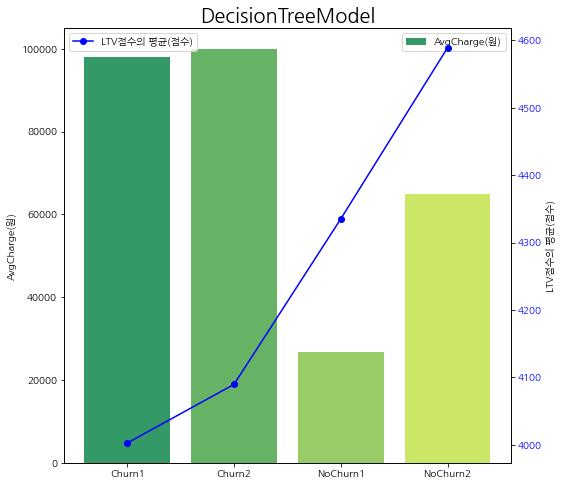

```python
fig = plt.figure(figsize=(8,8)) ## Figure 생성
fig.set_facecolor('white') ## Figure 배경색 지정
ax1 = fig.add_subplot() ## axes 생성

colors = sns.color_palette('summer', len(model)) ## 바 차트 색상

xtick_label_position = list(range(len(model))) ## x축 눈금 라벨이 표시될 x좌표
ax1.set_xticks(xtick_label_position) ## x축 눈금
ax1.set_xticklabels(model) ## x축 눈금 라벨
ax1.bar(xtick_label_position, final_1['AvgCharge(원)'], color=colors,label='AvgCharge(원)') ## 바차트 출력
ax1.set_ylabel('AvgCharge(원)')
plt.legend()

color = 'blue'
ax2 = ax1.twinx() ## 새로운 axis 생성
ax2.plot(xtick_label_position, final_1['LTV점수의 평균(점수)'], color=color, linestyle='-', marker='o',label='LTV점수의 평균(점수)') ## 선 그래프
ax2.tick_params(axis='y', labelcolor=color) ## 눈금 라벨 색상 지정
ax2.set_ylabel('LTV점수의 평균(점수)')

plt.title('DecisionTreeModel', fontsize=20)
plt.legend()
plt.show()
```

```python
final_2 = pd.DataFrame({'AvgDownloadGB' : [24.92,22.49,0,13.70],
                     'noService' : [0,0, 0, 0.94]})
```

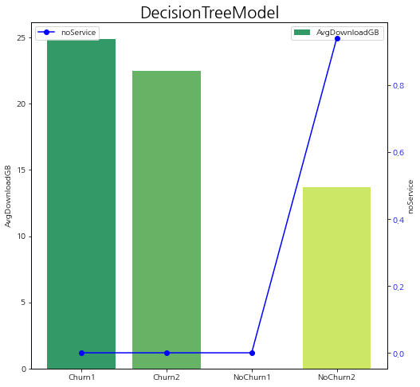

```python
fig = plt.figure(figsize=(8,8)) ## Figure 생성
fig.set_facecolor('white') ## Figure 배경색 지정
ax1 = fig.add_subplot() ## axes 생성

colors = sns.color_palette('summer', len(model)) ## 바 차트 색상

xtick_label_position = list(range(len(model))) ## x축 눈금 라벨이 표시될 x좌표
ax1.set_xticks(xtick_label_position) ## x축 눈금
ax1.set_xticklabels(model) ## x축 눈금 라벨
ax1.bar(xtick_label_position, final_2['AvgDownloadGB'], color=colors,label='AvgDownloadGB') ## 바차트 출력
ax1.set_ylabel('AvgDownloadGB')
plt.legend()

color = 'blue'
ax2 = ax1.twinx() ## 새로운 axis 생성
ax2.plot(xtick_label_position, final_2['noService'], color=color, linestyle='-', marker='o',label='noService') ## 선 그래프
ax2.tick_params(axis='y', labelcolor=color) ## 눈금 라벨 색상 지정
ax2.set_ylabel('noService')
plt.legend()

plt.title('DecisionTreeModel', fontsize=20)
plt.show()
```